# STOR 455 Midterm 2

You can write your R code for STOR 455 midterm 2 here. There is no need to submit your work in this file, but you can keep this file for future reference.

```r
library(readr)
library(polynom)
library(car)
library(leaps)
library(tidyverse)
library(titanic)

lego <- read_csv("lego.csv")
lego_rm_AP_na = subset(lego, is.na(Amazon_Price) == FALSE)

# Focus on two themes of "star wars" and "friends"
lego2 = subset(lego_rm_AP_na, Theme == 'Star Wars' | Theme == 'Friends')

Turtles2 = read_csv("Turtles2.csv")
source("ShowSubsets.R")
Turtles3 = subset(Turtles2, LifeStage == "Adult")

StateSAT = read_csv("StateSAT.csv")
Pulse = read_csv("Pulse.csv", show_col_types = FALSE)

data("titanic_train")

vehicles_all <- read_csv("UsedCars.csv", show_col_types = FALSE)
vehicles_3States = subset(vehicles_all, State=="NY"|State=="NC"|State=="CA")
ModelOfMyChoice = "3"
vehiclesSE= subset(vehicles_3States, Model==ModelOfMyChoice)
```

Interaction is when two variables are multiplied together In the anova table variable1:variable2 are the variables that are multiplied together

A nested F-test can show the indicator effect and the interaction effect For example:

```r
LegoMod = lm(Amazon_Price ~ Pieces + Theme + Pieces*Theme, data=lego2)
LegoMod_Reduced = lm(Amazon_Price~Pieces, data=lego2)
anova(LegoMod_Reduced, LegoMod)
```

```
Analysis of Variance Table

Model 1: Amazon_Price ~ Pieces
Model 2: Amazon_Price ~ Pieces + Theme + Pieces * Theme
  Res.Df    RSS Df Sum of Sq     F  Pr(>F)
1    181 247273
2    179 236943  2     10330 3.902 0.02194 *
---
Signif. codes:  0 ‘***’ 0.001 ‘**’ 0.01 ‘*’ 0.05 ‘.’ 0.1 ‘ ’ 1
```

Factor turns a categorical variable into something R understands called an indicator

```r
# Making dummy variables with the categorical predictor.
Turtles3$NoPrecip=(Turtles3$Weather==1)*1
Turtles3$Drizzle=(Turtles3$Weather==2)*1
Turtles3$Rain=(Turtles3$Weather==3)*1

# The dummy predictors reflect the uneven changes in group means. Here the third category "Rain" is the baseline when NoPrecip and Drizzle are 0.
modelW2 = lm(Annuli ~ NoPrecip + Drizzle, data = Turtles3)

# Equivalent model. But R uses the first category as the baseline.
# factor() converts a numerical vector into categorical.
modelW3=lm(Annuli~factor(Weather),data=Turtles3)

# A model with both quantitative and categorical predictors. Note here the effect of "Mass" is considered to be the same across different categories of "Weather."
modelW4=lm(Annuli~Mass+factor(Weather),data=Turtles3)
```

If I want to make a function that’s quadratic or cubic ANOVA also looks different if being used with a polynomial function I is used in the linear model to prevent a new variable from being created

```r
modSATquad2 = lm(SAT~Takers+I(Takers^2),data=StateSAT)

modSATcubic = lm(SAT~Takers+I(Takers^2)+I(Takers^3),data=StateSAT)

# If we want to go even higher with the degrees
modSAT10 = lm(SAT~poly(Takers, degree=10, raw=TRUE), data=StateSAT)
```

A model may reflect the structure of a particular sample but not generalize well to the population The cross validation correlation between predicted and actual response values for a holdout sample Remember that shrinkage in cross validation can be negative. The holdout sample is a random sample from a data set that is withheld and not used in the model fitting process Training R^2 - Holdout R^2 is known as the shrinkage Generally since the model is optimized by the training data we expect less R^2 for the holdout

```r
# Cross validation illustrated with "Pulse.csv"
set.seed(12345)
# reording rows of the data
rows <- sample(nrow(Pulse))
Pulse_shuffled = Pulse[rows,]

# Taking a subset of 80% observations at random as the training data
PulseTrain=Pulse_shuffled[1:300,]
# Using the rest 20% data as testing data
PulseHoldout=Pulse_shuffled[301:375,]

# Creates the full model, the none model, and the MSE(Mean Squared Error)
full = lm(Active~Rest + Hgt + Wgt + Sex + Smoke + factor(Exercise), data=PulseTrain)
none = lm(Active~1, data=PulseTrain)
MSE = (summary(full)$sigma)^2

PulseTrainMod = step(none, scope = list(upper=full), scale=MSE, trace=FALSE)

# Uses the training model and the testing data to predict active heart rates
fitActive=predict(PulseTrainMod,newdata=PulseHoldout)

# Change in r^2 from the training to the holdout
crosscorr=cor(PulseHoldout$Active,fitActive)
shrinkage = summary(PulseTrainMod)$r.squared-crosscorr^2

# Shows cases with a high Cook's Distance
Cooks_indices = which(cooks.distance(full) >= 0.5)
```

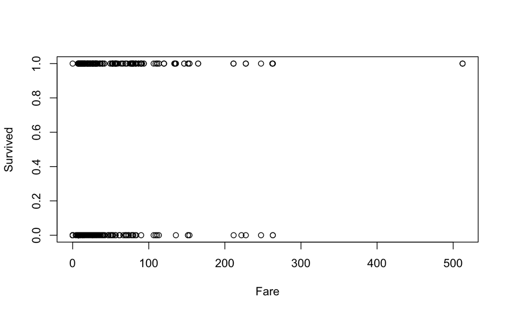

```r
# Use glm() to fit a generalized linear model.
# Binary variables can be modeled through the binomial distribution.
# The code belows fit a logistic regression (a special case of a generalized linear model).
Titanic_logitmod = glm(Survived ~ Fare, family = binomial, data=titanic_train)
plot(Survived~Fare, data=titanic_train)
```

Model selection methods

```r
Full = lm(Price~State+Mileage+Year+Year*State+Mileage*State+I(Mileage)^2, data = vehiclesSE)

all = regsubsets(Price~State+Mileage+Year+Year*State+Mileage*State+I(Mileage)^2, data = vehiclesSE)
```

```
Reordering variables and trying again:
```

```r
summary(all)
```

```
Subset selection object
Call: regsubsets.formula(Price ~ State + Mileage + Year + Year * State +
    Mileage * State + I(Mileage)^2, data = vehiclesSE)
9 Variables  (and intercept)
                Forced in Forced out
StateNC             FALSE      FALSE
StateNY             FALSE      FALSE
Mileage             FALSE      FALSE
Year                FALSE      FALSE
StateNC:Year        FALSE      FALSE
StateNY:Year        FALSE      FALSE
StateNC:Mileage     FALSE      FALSE
StateNY:Mileage     FALSE      FALSE
I(Mileage)          FALSE      FALSE
1 subsets of each size up to 8
Selection Algorithm: exhaustive
         StateNC StateNY Mileage Year I(Mileage) StateNC:Year StateNY:Year StateNC:Mileage StateNY:Mileage
1  ( 1 ) " "     " "     " "     " "  "*"        " "          " "          " "             " "
2  ( 1 ) " "     " "     " "     "*"  "*"        " "          " "          " "             " "
3  ( 1 ) " "     " "     " "     "*"  "*"        " "          " "          "*"             " "
4  ( 1 ) " "     "*"     "*"     "*"  " "        " "          "*"          " "             " "
5  ( 1 ) " "     "*"     " "     "*"  "*"        " "          "*"          "*"             " "
6  ( 1 ) " "     "*"     " "     "*"  "*"        "*"          "*"          "*"             " "
7  ( 1 ) "*"     "*"     "*"     "*"  " "        "*"          "*"          "*"             " "
8  ( 1 ) "*"     "*"     "*"     "*"  " "        "*"          "*"          "*"             "*"
```

```r
# Backward elimination
MSE = (summary(Full)$sigma)^2
step(Full, scale=MSE)
```

```
Start:  AIC=9
Price ~ State + Mileage + Year + Year * State + Mileage * State +
    I(Mileage)^2


Step:  AIC=9
Price ~ State + Mileage + Year + State:Year + State:Mileage

                Df Sum of Sq        RSS      Cp
- State:Mileage  2  31870188 7.4098e+10  6.3042
<none>                       7.4066e+10  9.0000
- State:Year     2 184791773 7.4250e+10 12.5623

Step:  AIC=6.3
Price ~ State + Mileage + Year + State:Year

             Df  Sum of Sq        RSS       Cp
<none>                     7.4098e+10   6.3042
- State:Year  2 7.2682e+08 7.4824e+10  32.0480
- Mileage     1 2.3028e+10 9.7126e+10 946.6865

Call:
lm(formula = Price ~ State + Mileage + Year + State:Year, data = vehiclesSE)

Coefficients:
 (Intercept)       StateNC       StateNY       Mileage          Year  StateNC:Year  StateNY:Year
  -2.186e+06     2.956e+05    -7.509e+05    -1.453e-01     1.101e+03    -1.468e+02     3.732e+02
```

```r
# Forward selection
none = lm(Price~1, data = vehiclesSE)
step(none, scope = list(upper=Full), scale = MSE, direction = "forward")
```

```
Start:  AIC=10418.07
Price ~ 1

             Df  Sum of Sq        RSS       Cp
+ Mileage     1 2.4076e+11 8.8058e+10   567.59
+ I(Mileage)  1 2.4076e+11 8.8058e+10   567.59
+ Year        1 2.3088e+11 9.7933e+10   971.71
+ State       2 4.6596e+09 3.2415e+11 10231.39
<none>                     3.2881e+11 10418.07

Step:  AIC=567.59
Price ~ Mileage

        Df  Sum of Sq        RSS      Cp
+ Year   1 1.3151e+10 7.4907e+10  31.419
<none>                8.8058e+10 567.592
+ State  2 7.8604e+07 8.7979e+10 568.375

Step:  AIC=31.42
Price ~ Mileage + Year

        Df Sum of Sq        RSS     Cp
<none>               7.4907e+10 31.419
+ State  2  82363970 7.4824e+10 32.048

Call:
lm(formula = Price ~ Mileage + Year, data = vehiclesSE)

Coefficients:
(Intercept)      Mileage         Year
 -2.225e+06   -1.447e-01    1.120e+03
```

```r
# Stepwise regression
step(none, scope=list(upper=Full), scale = MSE)
```

```
Start:  AIC=10418.07
Price ~ 1

             Df  Sum of Sq        RSS       Cp
+ Mileage     1 2.4076e+11 8.8058e+10   567.59
+ I(Mileage)  1 2.4076e+11 8.8058e+10   567.59
+ Year        1 2.3088e+11 9.7933e+10   971.71
+ State       2 4.6596e+09 3.2415e+11 10231.39
<none>                     3.2881e+11 10418.07

Step:  AIC=567.59
Price ~ Mileage

          Df  Sum of Sq        RSS        Cp
+ Year     1 1.3151e+10 7.4907e+10    31.419
<none>                  8.8058e+10   567.592
+ State    2 7.8604e+07 8.7979e+10   568.375
- Mileage  1 2.4076e+11 3.2881e+11 10418.073

Step:  AIC=31.42
Price ~ Mileage + Year

          Df  Sum of Sq        RSS      Cp
<none>                  7.4907e+10  31.419
+ State    2 8.2364e+07 7.4824e+10  32.048
- Year     1 1.3151e+10 8.8058e+10 567.592
- Mileage  1 2.3026e+10 9.7933e+10 971.710

Call:
lm(formula = Price ~ Mileage + Year, data = vehiclesSE)

Coefficients:
(Intercept)      Mileage         Year
 -2.225e+06   -1.447e-01    1.120e+03
```